# practicalML_assignment

Joanna Tyszkiewicz Georgescu

February 16, 2019

## Overview

Using devices such as Jawbone Up, Nike FuelBand, and Fitbit it is now possible to collect a large amount of data about personal activity relatively inexpensively. These type of devices are part of the quantified self movement - a group of enthusiasts who take measurements about themselves regularly to improve their health, to find patterns in their behavior, or because they are tech geeks. One thing that people regularly do is quantify how much of a particular activity they do, but they rarely quantify how well they do it. In this project, your goal will be to use data from accelerometers on the belt, forearm, arm, and dumbell of 6 participants. They were asked to perform barbell lifts correctly and incorrectly in 5 different ways. More information is available from the website here: http://web.archive.org/web/20161224072740/http:/groupware.les.inf.puc-rio.br/har (see the section on the Weight Lifting Exercise Dataset).

## Data

The training data for this project are available here:

https://d396qusza40orc.cloudfront.net/predmachlearn/pml-training.csv

The test data are available here:

https://d396qusza40orc.cloudfront.net/predmachlearn/pml-testing.csv

## Methods

Load the data

Clean the data and remove features with missing values

```r
train_data <- read.csv('pml-training.csv', na.strings = c("NA", "#DIV/0!", ""))
test_data <- read.csv('pml-testing.csv', na.strings = c("NA", "#DIV/0!", ""))
clnColumnIndex <- colSums(is.na(train_data))/nrow(train_data) < 0.95
clean_train_data <- train_data[,clnColumnIndex]
colSums(is.na(clean_train_data))/nrow(clean_train_data)
```

```
##                    X            user_name raw_timestamp_part_1
##                    0                    0                    0
## raw_timestamp_part_2       cvtd_timestamp           new_window
##                    0                    0                    0
##           num_window            roll_belt           pitch_belt
##                    0                    0                    0
##             yaw_belt     total_accel_belt         gyros_belt_x
##                    0                    0                    0
##         gyros_belt_y         gyros_belt_z         accel_belt_x
##                    0                    0                    0
##         accel_belt_y         accel_belt_z        magnet_belt_x
##                    0                    0                    0
##        magnet_belt_y        magnet_belt_z             roll_arm
##                    0                    0                    0
##            pitch_arm              yaw_arm      total_accel_arm
##                    0                    0                    0
##          gyros_arm_x          gyros_arm_y          gyros_arm_z
##                    0                    0                    0
##          accel_arm_x          accel_arm_y          accel_arm_z
##                    0                    0                    0
##         magnet_arm_x         magnet_arm_y         magnet_arm_z
##                    0                    0                    0
##        roll_dumbbell       pitch_dumbbell         yaw_dumbbell
##                    0                    0                    0
## total_accel_dumbbell     gyros_dumbbell_x     gyros_dumbbell_y
##                    0                    0                    0
##     gyros_dumbbell_z     accel_dumbbell_x     accel_dumbbell_y
##                    0                    0                    0
##     accel_dumbbell_z    magnet_dumbbell_x    magnet_dumbbell_y
##                    0                    0                    0
##    magnet_dumbbell_z         roll_forearm        pitch_forearm
##                    0                    0                    0
##          yaw_forearm  total_accel_forearm      gyros_forearm_x
##                    0                    0                    0
##      gyros_forearm_y      gyros_forearm_z      accel_forearm_x
##                    0                    0                    0
##      accel_forearm_y      accel_forearm_z     magnet_forearm_x
##                    0                    0                    0
##     magnet_forearm_y     magnet_forearm_z               classe
##                    0                    0                    0
```

```r
colSums(is.na(clean_train_data))
```

```
##                    X            user_name raw_timestamp_part_1
##                    0                    0                    0
## raw_timestamp_part_2       cvtd_timestamp           new_window
##                    0                    0                    0
##           num_window            roll_belt           pitch_belt
##                    0                    0                    0
##             yaw_belt     total_accel_belt         gyros_belt_x
##                    0                    0                    0
##         gyros_belt_y         gyros_belt_z         accel_belt_x
##                    0                    0                    0
##         accel_belt_y         accel_belt_z        magnet_belt_x
##                    0                    0                    0
##        magnet_belt_y        magnet_belt_z             roll_arm
##                    0                    0                    0
##            pitch_arm              yaw_arm      total_accel_arm
##                    0                    0                    0
##          gyros_arm_x          gyros_arm_y          gyros_arm_z
##                    0                    0                    0
##          accel_arm_x          accel_arm_y          accel_arm_z
##                    0                    0                    0
##         magnet_arm_x         magnet_arm_y         magnet_arm_z
##                    0                    0                    0
##        roll_dumbbell       pitch_dumbbell         yaw_dumbbell
##                    0                    0                    0
## total_accel_dumbbell     gyros_dumbbell_x     gyros_dumbbell_y
##                    0                    0                    0
##     gyros_dumbbell_z     accel_dumbbell_x     accel_dumbbell_y
##                    0                    0                    0
##     accel_dumbbell_z    magnet_dumbbell_x    magnet_dumbbell_y
##                    0                    0                    0
##    magnet_dumbbell_z         roll_forearm        pitch_forearm
##                    0                    0                    0
##          yaw_forearm  total_accel_forearm      gyros_forearm_x
##                    0                    0                    0
##      gyros_forearm_y      gyros_forearm_z      accel_forearm_x
##                    0                    0                    0
##      accel_forearm_y      accel_forearm_z     magnet_forearm_x
##                    0                    0                    0
##     magnet_forearm_y     magnet_forearm_z               classe
##                    0                    0                    0
```

Remove irrelevant features (1-7)

```r
clean_train_data <- clean_train_data[,-c(1:7)]
clean_test_data <- test_data[,-c(1:7)]
```

Split into train and test sets

```r
inTrInd <- createDataPartition(clean_train_data$classe, p=0.7)[[1]]
train_set <- clean_train_data[inTrInd,]
val_set <- clean_train_data[-inTrInd,]
```

Visualize correlation between features

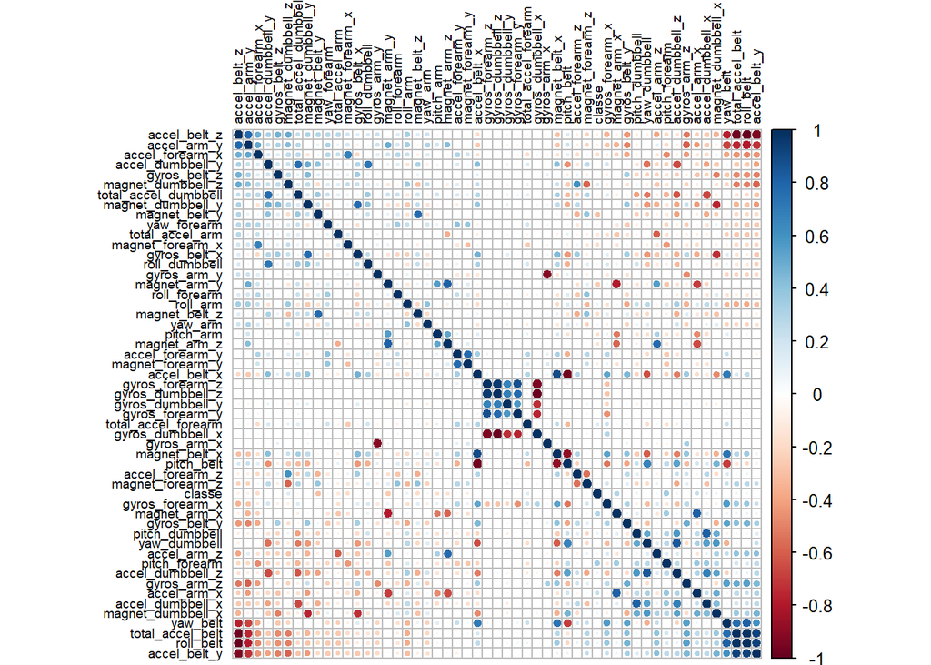

```r
correlationMatrix <-cor(data.matrix(train_set)[, -54])
corrplot(correlationMatrix, order="FPC", method="circle", type="full",tl.col="black",  tl.cex = 0.6)
```

Two algorithms, Decision Tree and Random Forest, are next applied to model the regressions and the algorithm with higher accuracy is used for final redictions.

Algorithm 1: Decision tree

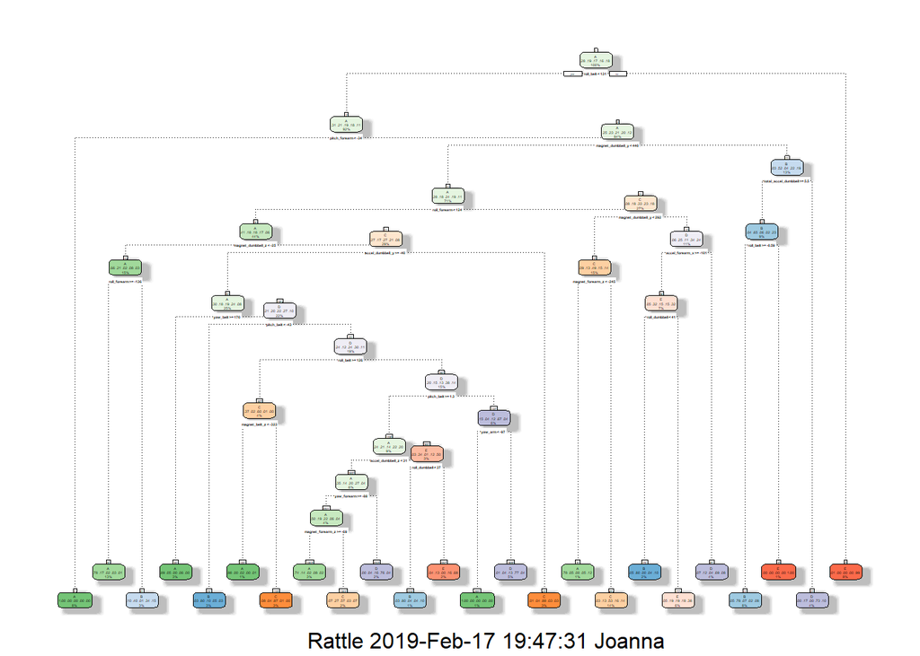

```r
set.seed(12345)
dTreeMod <- rpart(classe ~ ., data=train_set, method="class")
fancyRpartPlot(dTreeMod)
```

```r
valdTreeMod <- predict(dTreeMod, val_set, type = "class")
vdTreeMod <- confusionMatrix(valdTreeMod, val_set$classe)
vdTreeMod
```

```
## Confusion Matrix and Statistics
##
##           Reference
## Prediction    A    B    C    D    E
##          A 1527  176   14   58   13
##          B   49  633   58   81   78
##          C   56  178  840  142  161
##          D   17   71   53  624   61
##          E   25   81   61   59  769
##
## Overall Statistics
##
##                Accuracy : 0.7465
##                  95% CI : (0.7352, 0.7575)
##     No Information Rate : 0.2845
##     P-Value [Acc > NIR] : < 2.2e-16
##
##                   Kappa : 0.6787
##  Mcnemar's Test P-Value : < 2.2e-16
##
## Statistics by Class:
##
##                      Class: A Class: B Class: C Class: D Class: E
## Sensitivity            0.9122   0.5558   0.8187   0.6473   0.7107
## Specificity            0.9380   0.9440   0.8895   0.9590   0.9529
## Pos Pred Value         0.8540   0.7041   0.6100   0.7554   0.7729
## Neg Pred Value         0.9641   0.8985   0.9587   0.9328   0.9360
## Prevalence             0.2845   0.1935   0.1743   0.1638   0.1839
## Detection Rate         0.2595   0.1076   0.1427   0.1060   0.1307
## Detection Prevalence   0.3038   0.1528   0.2340   0.1404   0.1691
## Balanced Accuracy      0.9251   0.7499   0.8541   0.8031   0.8318
```

Decision tree accuracy = 0.75

Algorithm 2: Random forest

```r
set.seed(12345)
rforestMod <- train(classe ~., method='rf', data=train_set, ntree=128)
rforestMod$finalModel
```

```
##
## Call:
##  randomForest(x = x, y = y, ntree = 128, mtry = param$mtry)
##                Type of random forest: classification
##                      Number of trees: 128
## No. of variables tried at each split: 27
##
##         OOB estimate of  error rate: 0.73%
## Confusion matrix:
##      A    B    C    D    E class.error
## A 3898    5    2    0    1 0.002048131
## B   18 2625   12    2    1 0.012415350
## C    0    7 2381    8    0 0.006260434
## D    0    1   33 2217    1 0.015541741
## E    0    0    4    5 2516 0.003564356
```

```r
valrforestMod <- predict(rforestMod , newdata=val_set)
crforest <- confusionMatrix(valrforestMod, val_set$classe)
crforest
```

```
## Confusion Matrix and Statistics
##
##           Reference
## Prediction    A    B    C    D    E
##          A 1671    5    0    0    0
##          B    0 1130    7    0    0
##          C    2    4 1017    9    0
##          D    0    0    2  952    3
##          E    1    0    0    3 1079
##
## Overall Statistics
##
##                Accuracy : 0.9939
##                  95% CI : (0.9915, 0.9957)
##     No Information Rate : 0.2845
##     P-Value [Acc > NIR] : < 2.2e-16
##
##                   Kappa : 0.9923
##  Mcnemar's Test P-Value : NA
##
## Statistics by Class:
##
##                      Class: A Class: B Class: C Class: D Class: E
## Sensitivity            0.9982   0.9921   0.9912   0.9876   0.9972
## Specificity            0.9988   0.9985   0.9969   0.9990   0.9992
## Pos Pred Value         0.9970   0.9938   0.9855   0.9948   0.9963
## Neg Pred Value         0.9993   0.9981   0.9981   0.9976   0.9994
## Prevalence             0.2845   0.1935   0.1743   0.1638   0.1839
## Detection Rate         0.2839   0.1920   0.1728   0.1618   0.1833
## Detection Prevalence   0.2848   0.1932   0.1754   0.1626   0.1840
## Balanced Accuracy      0.9985   0.9953   0.9941   0.9933   0.9982
```

Random forest accuracy = 0.99

Use the model with higher accuracy - random forest, on the test dataset

```r
finalResult <- predict(rforestMod, newdata=clean_test_data )
finalResult
```

```
##  [1] B A B A A E D B A A B C B A E E A B B B
## Levels: A B C D E
```

## Results

The finalResult will be used to answer practical ML quiz 4 quesions.